# L15: Simple linear regression

28 June 2017

# 1 Linear regression in R

Simple linear regression model describe the effect of the explanatory variable (X) on the response variable (Y). Explanatory variable may be contonous, discrete, or categorical.

It is important to assume following for the error term:

1. Normal distribution of error with N (0,sigma)
2. That errors are centered, which means that mean of the errors is equal to 0.
3. The variance of the errors is sigma squared and it is constant.

We need to estimate regression coefficients: B0 - intercept B1 - slope.

When we find intecept we could conclude that for every unit increase in X, Y increases for the value of the slope (B1).

The data give the diameter of plants in mm and the amount of seed each plant produced in g.

We are interested in how seed production is affected by plant size, as indicated by root diameter.

Housekeeping

```r
rm(list=ls()) # remove everything currently held in the R memory
```

# 2 Enter or read in your data from a file

Read in data from our CSV (comma separated value) file

If you need any help for import of the data, take a look at Lesson 3 course material.

Remember that the data file should be in your working directory before you import the file to R.

```r
mydata <- read.table("grazing.csv", header=TRUE, sep=",")
```

# 3 Plot and explore your data

If we want to see first six rows of our data we could use function head (name of the dataset) as follows:

First explore:

```r
head(mydata)
```

```
##    Root  Seed
## 1 6.225 59.77
## 2 6.487 60.98
## 3 4.919 14.73
## 4 5.130 19.28
## 5 5.417 34.25
## 6 5.359 35.53
```

then plot

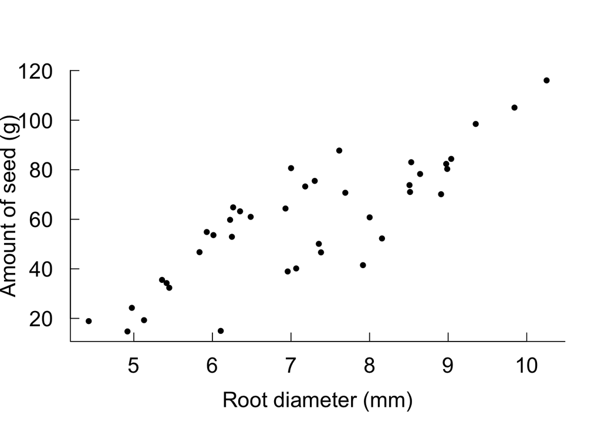

```r
plot(mydata$Root,mydata$Seed,type="p", xlab="Root diameter (mm)", ylab="Amount of seed (g)", pch=20 ,
        cex.lab=1.5, cex.axis=1.5, cex=1.2,
        bty="L", las=1, tcl=0.5 ) # type = p - this p is for points
```

# 4 Analyse your data

We want to see how root size influences seed size.

```r
model1 <- lm(mydata$Seed~mydata$Root) # model 1 will store information on linear model where Y axis variable is Seed and X axis variable is Root.

model1 # we can see formula and coefficients of linear model
```

```
##
## Call:
## lm(formula = mydata$Seed ~ mydata$Root)
##
## Coefficients:
## (Intercept)  mydata$Root
##      -41.29        14.02
```

```r
summary(model1)
```

```
##
## Call:
## lm(formula = mydata$Seed ~ mydata$Root)
##
## Residuals:
##      Min       1Q   Median       3Q      Max
## -29.3844 -10.4447  -0.7574  10.7606  23.7556
##
## Coefficients:
##             Estimate Std. Error t value Pr(>|t|)
## (Intercept)  -41.286     10.723  -3.850 0.000439 ***
## mydata$Root   14.022      1.463   9.584  1.1e-11 ***
## ---
## Signif. codes:  0 '***' 0.001 '**' 0.01 '*' 0.05 '.' 0.1 ' ' 1
##
## Residual standard error: 13.52 on 38 degrees of freedom
## Multiple R-squared:  0.7073, Adjusted R-squared:  0.6996
## F-statistic: 91.84 on 1 and 38 DF,  p-value: 1.099e-11
```

R-squared and adjusted R-squared explain how good is your model. If the value is close to 1 than your model is good, if the value is close to 0 your model is bad. This model is reasonably good while its value is 0.7 which is closer to 1 than to 0.

# 5 Plot the results of your analysis

abline() adds the best fit line

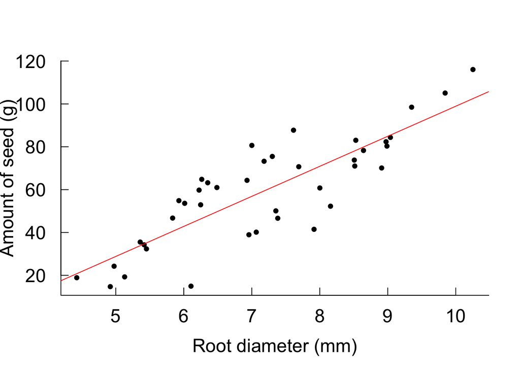

```r
plot(mydata$Root,mydata$Seed,type="p", xlab="Root diameter (mm)", ylab="Amount of seed (g)", pch=20 ,
        cex.lab=1.5, cex.axis=1.5, cex=1.2,
        bty="L", las=1, tcl=0.5 ) # type = p - this p is for points
abline(model1,col="red")
```

# 6 Extract the residuals for easy recall

```r
rsd <- residuals(model1)
```

# 7 Histogram of the residuals

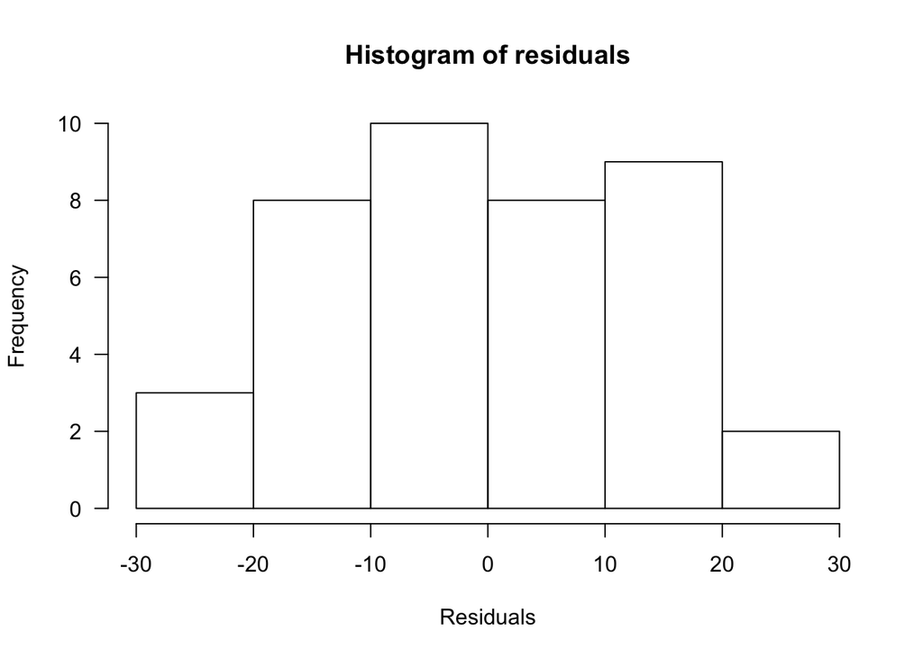

```r
hist(rsd, main="Histogram of residuals", xlab="Residuals", ylab="Frequency", las=1)
```

QQ plot of the residuals to assess how well the residuals compare with an ideal normal distribution

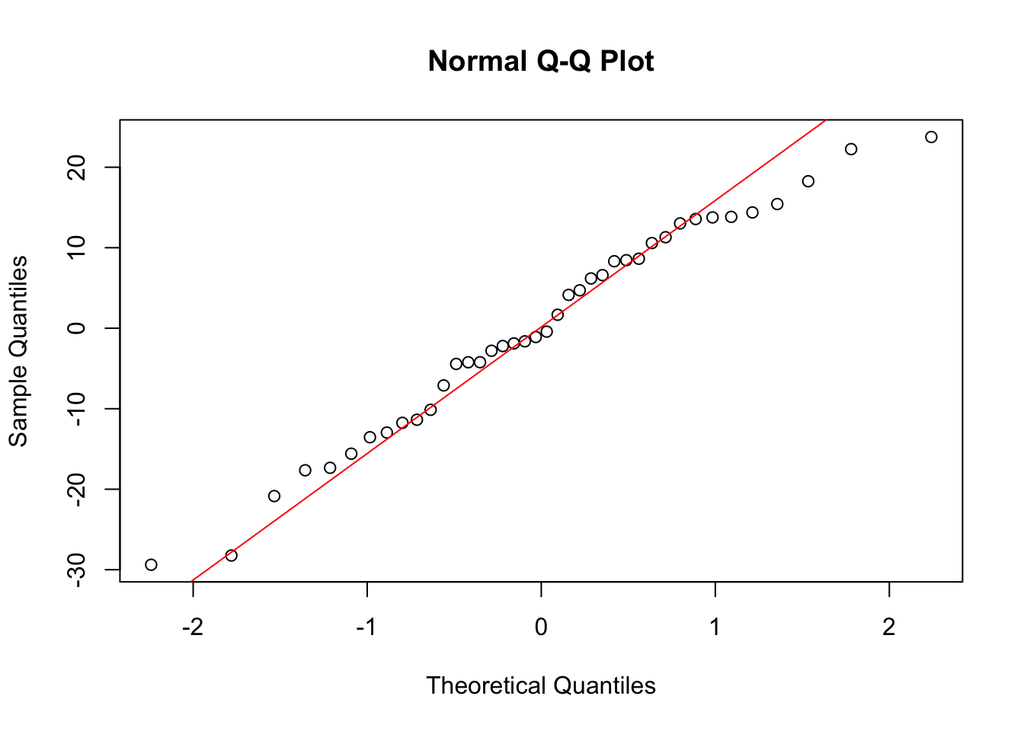

```r
qqnorm(rsd)
qqline(rsd,col="red")
```

Check for a trend in the residuals with the X axis variable

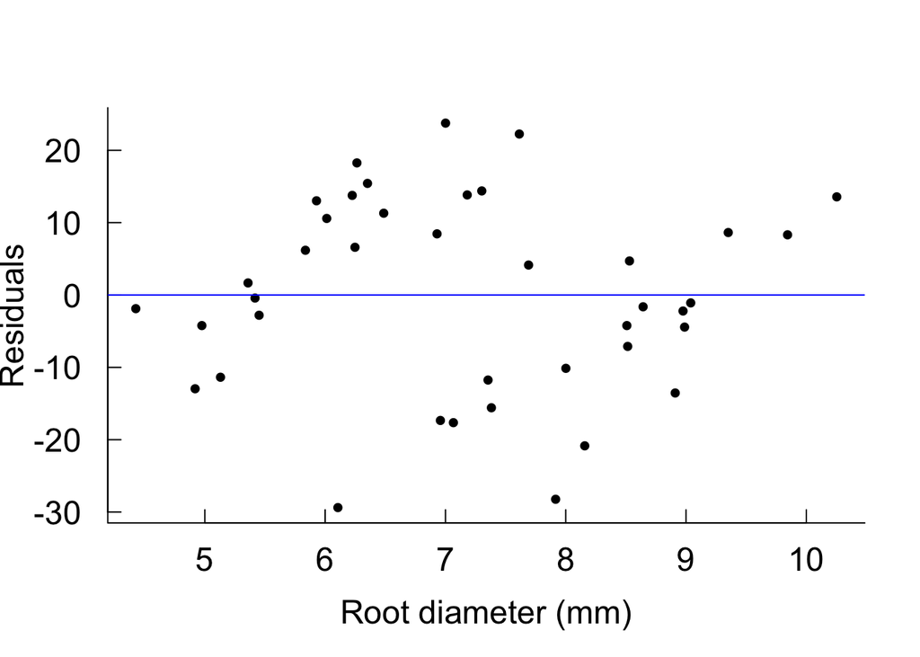

```r
plot(mydata$Root,rsd,type="p", xlab="Root diameter (mm)", ylab="Residuals", pch=20 ,
        cex.lab=1.5, cex.axis=1.5, cex=1.2,
        bty="L", las=1, tcl=0.5 ) # type = p - this p is for points
abline(0,0,col="blue")
```

We see some data under the curve (overestimation), thereafter above the line (underestimation), then again under the line and then again over the line.

If we make a graph of real values with the model and residuals we can see clearly these paterrns.

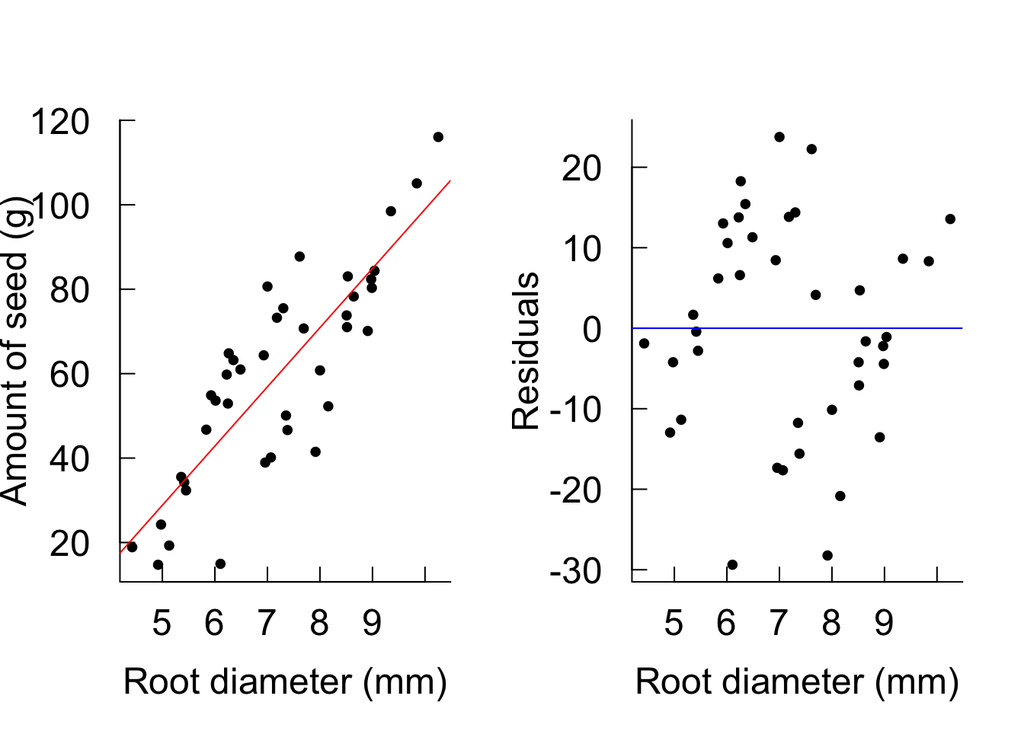

```r
par(mfrow=c(1,2))
plot(mydata$Root,mydata$Seed,type="p", xlab="Root diameter (mm)", ylab="Amount of seed (g)", pch=20 ,
        cex.lab=1.5, cex.axis=1.5, cex=1.2,
        bty="L", las=1, tcl=0.5 ) # type = p - this p is for points
abline(model1,col="red")
plot(mydata$Root,rsd,type="p", xlab="Root diameter (mm)", ylab="Residuals", pch=20 ,
        cex.lab=1.5, cex.axis=1.5, cex=1.2,
        bty="L", las=1, tcl=0.5 ) # type = p - this p is for points
abline(0,0,col="blue")
```

# 8 Save your data (only if you want)

The “list=” command tells us which variables we want to save

The “file=” option tells us what file to save the data to

```r
save( list=ls(), file="grazing_data.rdata" )
```

ASSIGNMENT:

Install car package, load a Prestige dataset and make a new data set called new with just these two variables. Then make a linear regression where education is on x axis and income on y-axis and explain results. Check residuals.

Solution:

```r
library(car)
head(Prestige,5)
```

```
##                     education income women prestige census type
## gov.administrators      13.11  12351 11.16     68.8   1113 prof
## general.managers        12.26  25879  4.02     69.1   1130 prof
## accountants             12.77   9271 15.70     63.4   1171 prof
## purchasing.officers     11.42   8865  9.11     56.8   1175 prof
## chemists                14.62   8403 11.68     73.5   2111 prof
```

```r
str(Prestige)
```

```
## 'data.frame':    102 obs. of  6 variables:
##  $ education: num  13.1 12.3 12.8 11.4 14.6 ...
##  $ income   : int  12351 25879 9271 8865 8403 11030 8258 14163 11377 11023 ...
##  $ women    : num  11.16 4.02 15.7 9.11 11.68 ...
##  $ prestige : num  68.8 69.1 63.4 56.8 73.5 77.6 72.6 78.1 73.1 68.8 ...
##  $ census   : int  1113 1130 1171 1175 2111 2113 2133 2141 2143 2153 ...
##  $ type     : Factor w/ 3 levels "bc","prof","wc": 2 2 2 2 2 2 2 2 2 2 ...
```

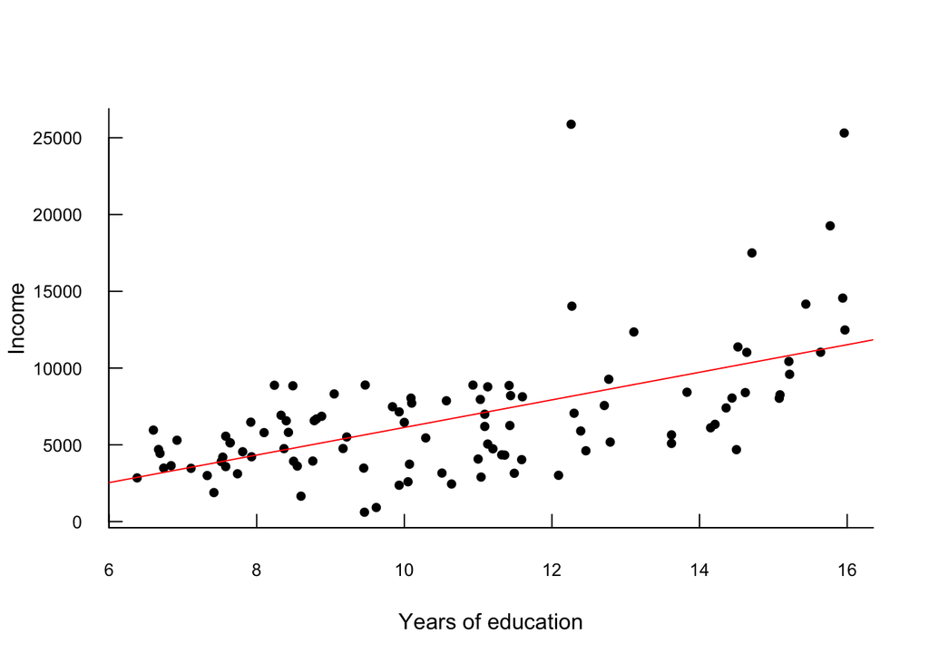

```r
new <- Prestige[,c(1:2)]
plot(new$education,new$income,type="p", xlab="Years of education", ylab="Income", pch=20 ,
        cex.lab=1, cex.axis=0.8, cex=1.2,
        bty="L", las=1, tcl=0.5)
modelx <- lm(new$income~new$education)
abline(modelx,col="red")
```

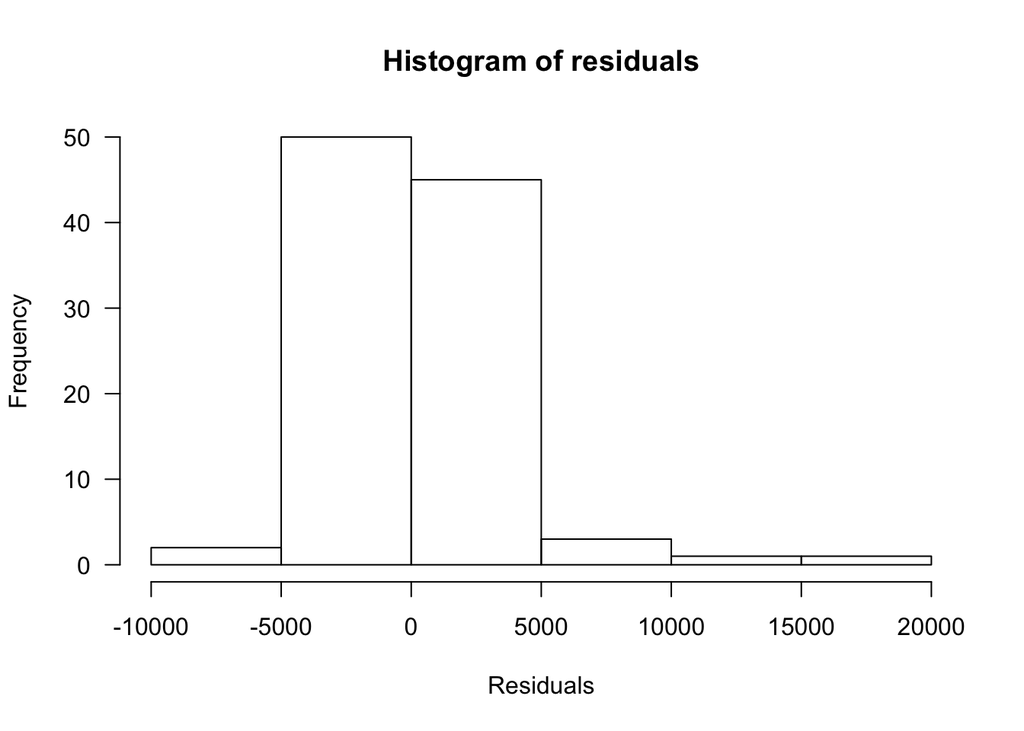

```r
rsdx <- residuals(modelx)
hist(rsdx, main="Histogram of residuals", xlab="Residuals", ylab="Frequency", las=1)
```

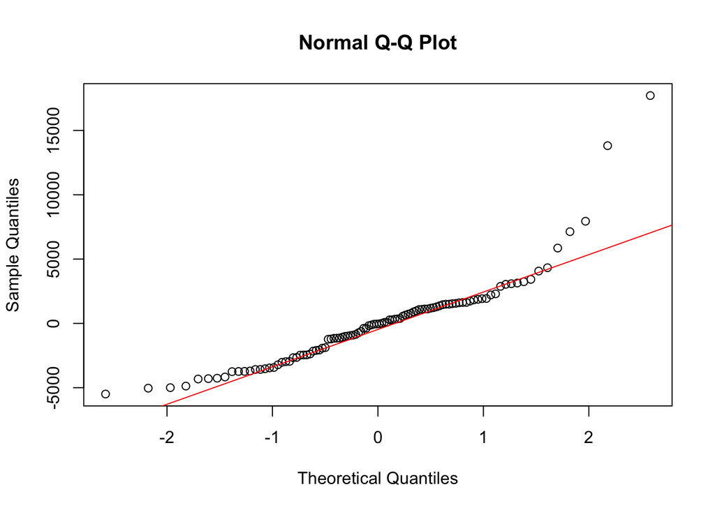

```r
qqnorm(rsdx)
qqline(rsdx,col="red")
```

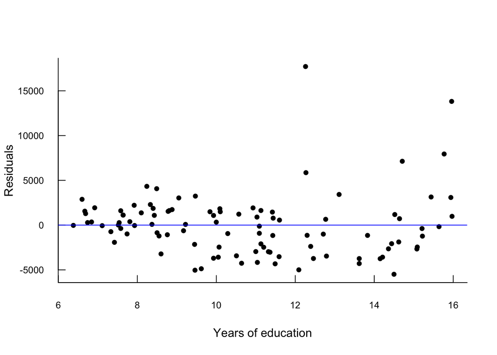

```r
plot(new$education,rsdx,type="p", xlab="Years of education", ylab="Residuals", pch=20 ,
        cex.lab=1, cex.axis=0.8, cex=1.2,
        bty="L", las=1, tcl=0.5) # type = p - this p is for points
abline(0,0,col="blue")
```